# Data Mining - Predicting Customer Churn

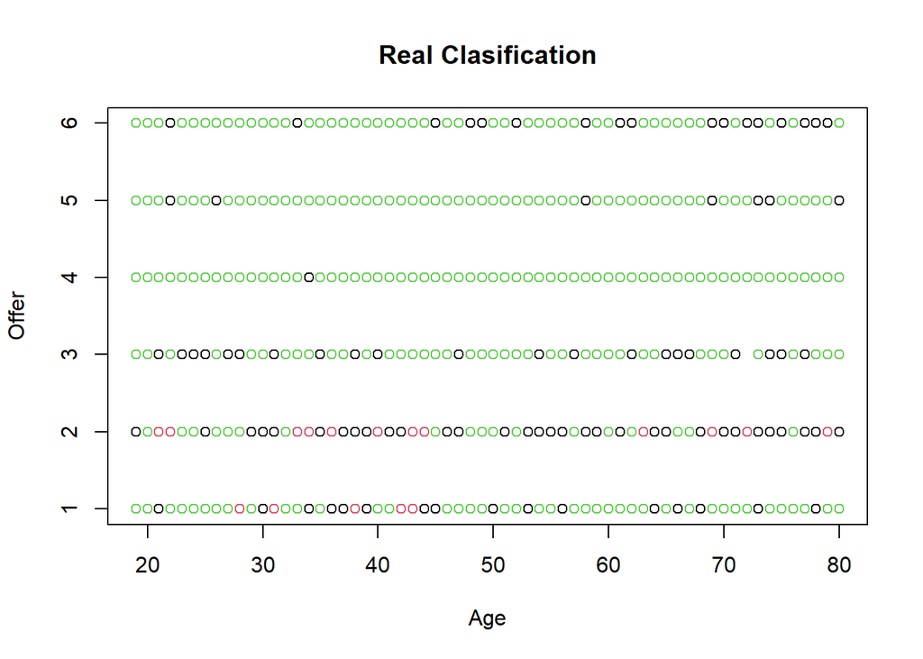

```r
plot(telecomNumericData[c(2,8)], col=as.factor(telecomCleanData$Customer.Status), main="Real Clasification")
```

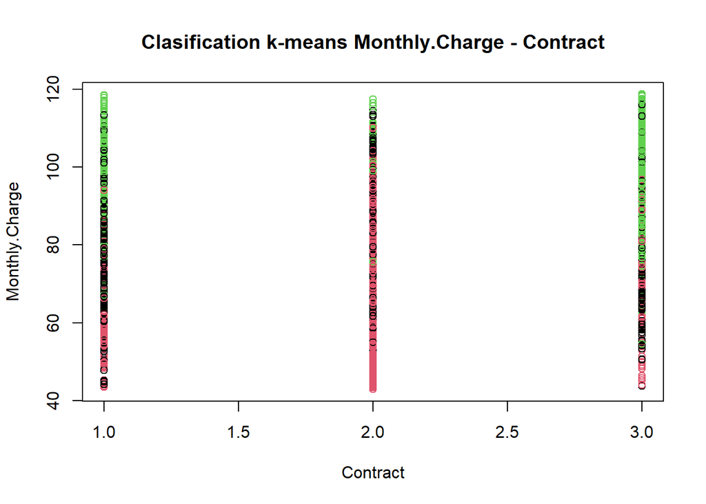

```r
plot(telecomNumericData[c(23,26)], col=telecom3clusters$cluster, main="Clasification k-means Monthly.Charge - Contract")
```

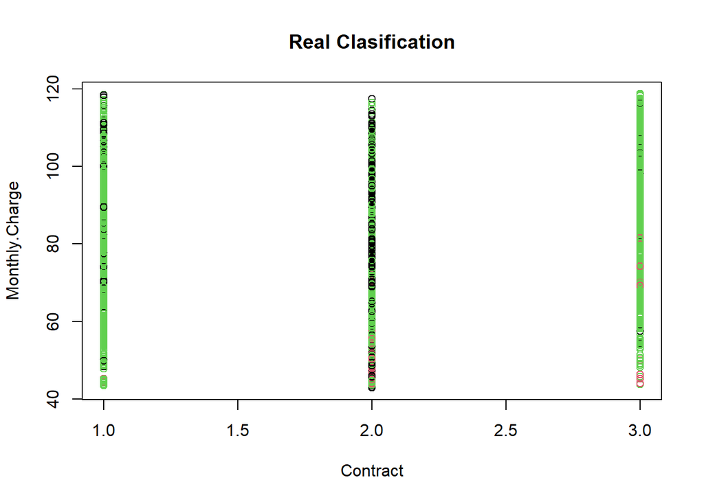

```r
plot(telecomNumericData[c(23,26)], col=as.factor(telecomCleanData$Customer.Status), main="Real Clasification")
```

We can note that the differences with the real classification are visible, they are not grouped very well. This is largely due to the fact that it makes 3 groups of equal size, when in reality this is not the case.

```r
print(table(telecomCleanData$Customer.Status))
```

```
##
## Churned  Joined  Stayed
##    1563     230    2959
```

## 3.1 Comparison of both Unsupervised Models

We can observe that the new clients are much less in comparison with the rest, and at the same time, those who leave are half of those who stay. We can try to make the previous graphs but with 2 clusters, leaving out the Joined group, to see if the other two can be grouped in a decent way.

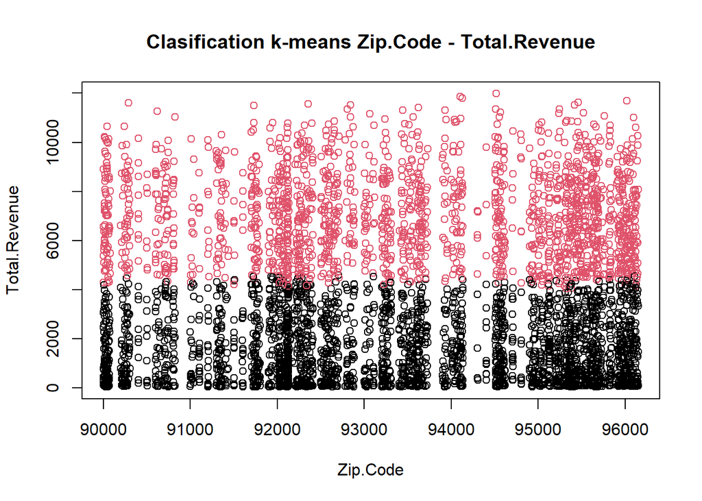

```r
telecom2clusters <- kmeans(telecomNumericData, 2)

plot(telecomNumericData[c(5,31)], col=telecom2clusters$cluster, main="Clasification k-means Zip.Code - Total.Revenue")
```

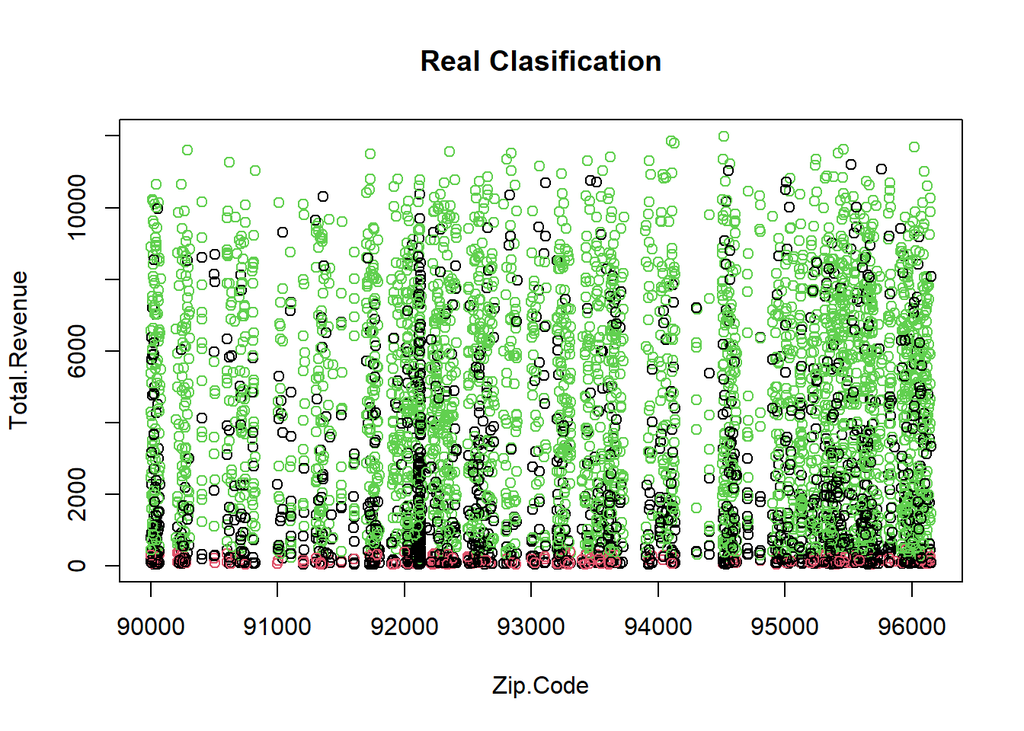

```r
plot(telecomNumericData[c(5,31)], col=as.factor(telecomCleanData$Customer.Status), main="Real Clasification")
```

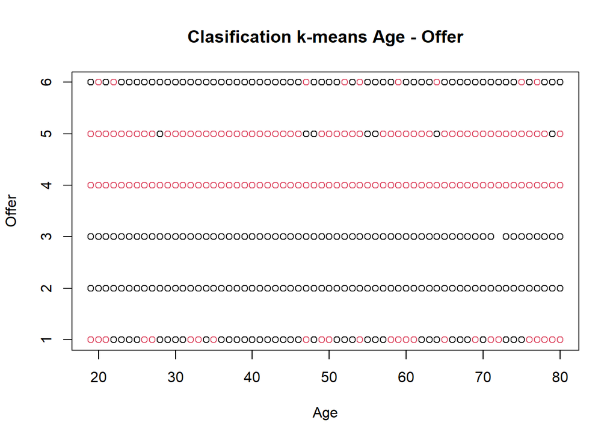

```r
plot(telecomNumericData[c(2,8)], col=telecom2clusters$cluster, main="Clasification k-means Age - Offer")
```

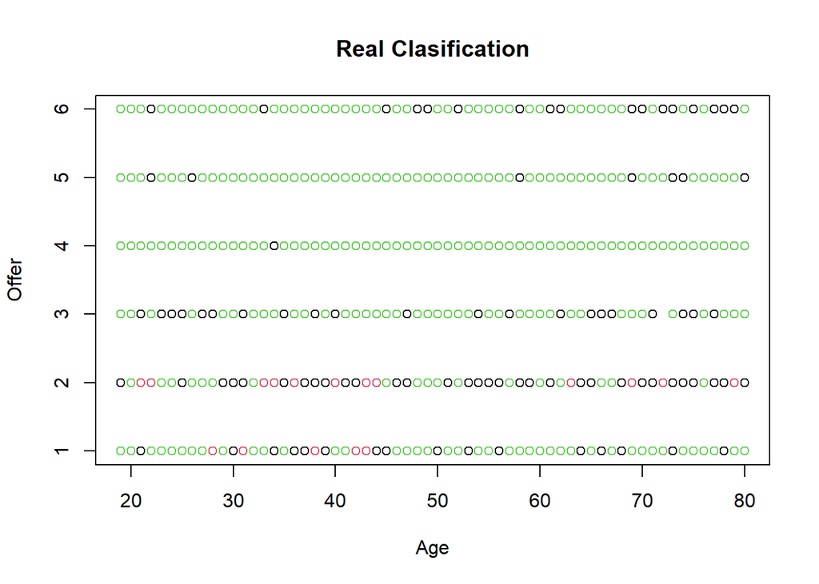

```r
plot(telecomNumericData[c(2,8)], col=as.factor(telecomCleanData$Customer.Status), main="Real Clasification")
```

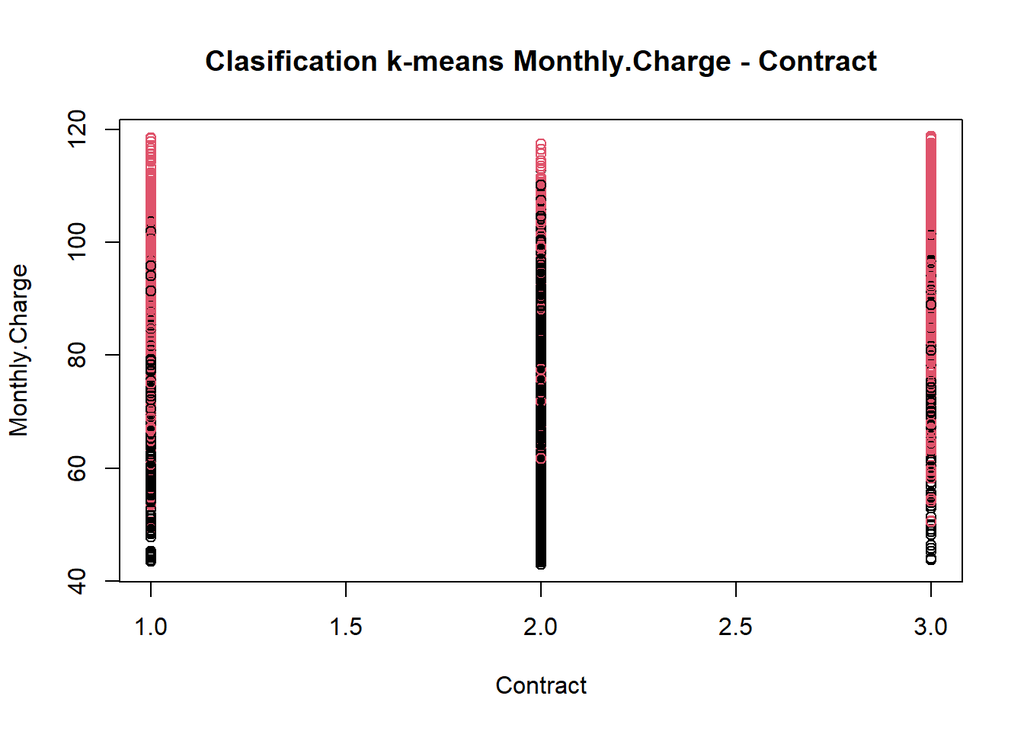

```r
plot(telecomNumericData[c(23,26)], col=telecom2clusters$cluster, main="Clasification k-means Monthly.Charge - Contract")
```

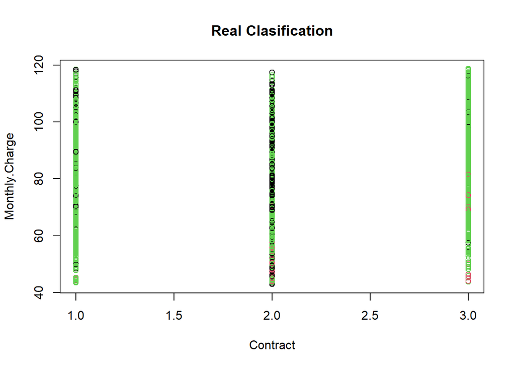

```r
plot(telecomNumericData[c(23,26)], col=as.factor(telecomCleanData$Customer.Status), main="Real Clasification")
```

We found that the zip code - total income and age - offer charts are not very accurate. However, the last one of monthly charge - type of contract, seems a little better. We can conclude that the 2 clusters model seems to be better than 3 clusters, since the joined group is very small, and we are not too interested in this particular analysis, since we want to predict when a customer is going to leave the company (churned).

# 4 DBSCAN and OPTICS algorithms

We are going to apply the OPTICS algorithm, which allows us to order the observations so that the nearest points become neighbors in the ordering. This algorithm does not require the number of clusters to be specified. We will first apply the algorithm with the default “minPts” and “eps” parameters.

```r
if (!require('dbscan')) install.packages('dbscan')
if (!require('fpc')) install.packages('fpc')
library(dbscan)
library(fpc)

res <- optics(telecomNumericData)
res
```

```
## OPTICS ordering/clustering for 4752 objects.
## Parameters: minPts = 5, eps = 1497.60589275016, eps_cl = NA, xi = NA
## Available fields: order, reachdist, coredist, predecessor, minPts, eps,
##                   eps_cl, xi
```

```r
res$order
```

[output not shown]

[output cut: 325 more lines]

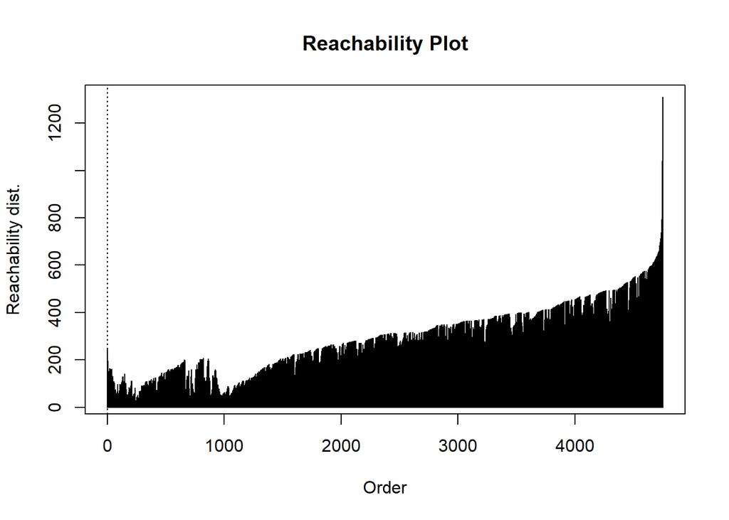

```r
plot(res)
```

We can observe that at the end there are some outliers, which indicate noise or outliers, since they are more distant from their immediate neighbors. However, the graph is almost always ascending from the first moment, so the groups will be very indistinguishable. If we play with the minPts and eps parameters, we can reduce or increase the noise. The minPts parameter tells us the minimum number of points that must be within a radius (eps) for a point to be considered ‘core’. If a point has at least ‘minPts’ points within an ‘eps’ radius, it is considered a core. And, therefore, eps specifies the maximum distance allowed between two points for one to be considered a neighbor of the other.

```r
res2 <- optics(telecomNumericData, minPts = 20, eps = 1000)
res2$order
```

[output not shown]

[output cut: 325 more lines]

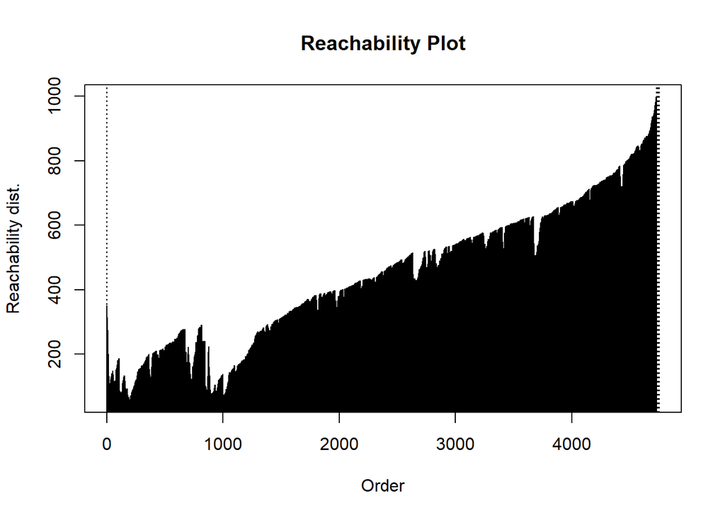

```r
plot(res2)
```

We observe that now with these parameters, the model has less noise at the end than the first one, but it is also even more bottom-up. From these models, we can now work with the DBSCAN algorithm. We will work with both to compare the quality of the models.

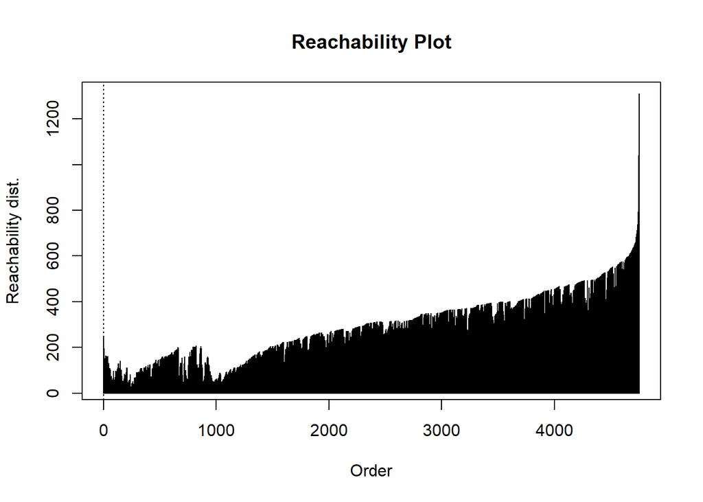

```r
clusters <- extractDBSCAN(res, eps_cl = .065)
plot(clusters)
```

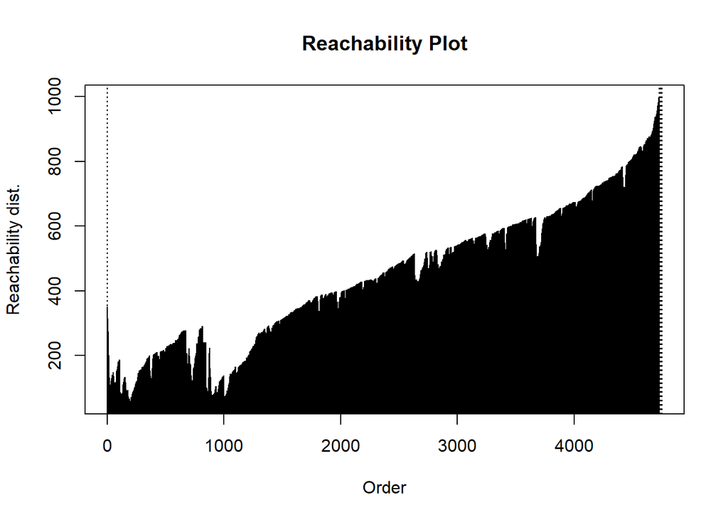

```r
clusters2 <- extractDBSCAN(res2, eps_cl = .065)
plot(clusters2)
```

The parameter eps_cl is very important, and if we apply the general value of 0.065, we observe that the plot comes out all black. This means that the value is too low and is grouping all the points in a single cluster or considering many points as noise.

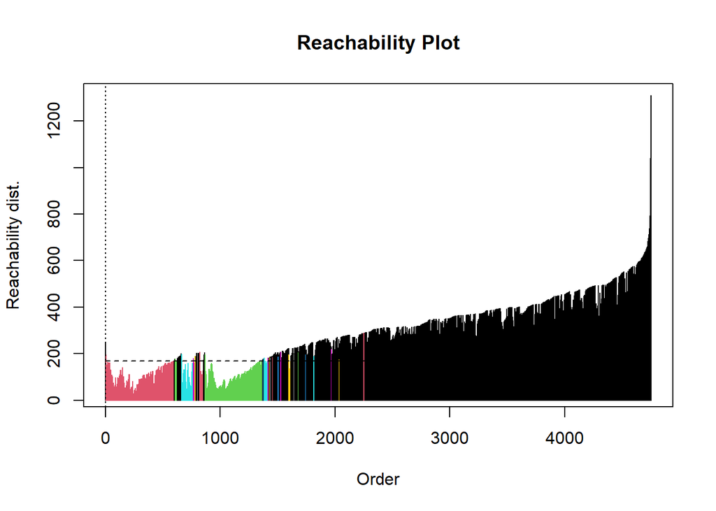

```r
clusters <- extractDBSCAN(res, eps_cl = 170)
plot(clusters)
```

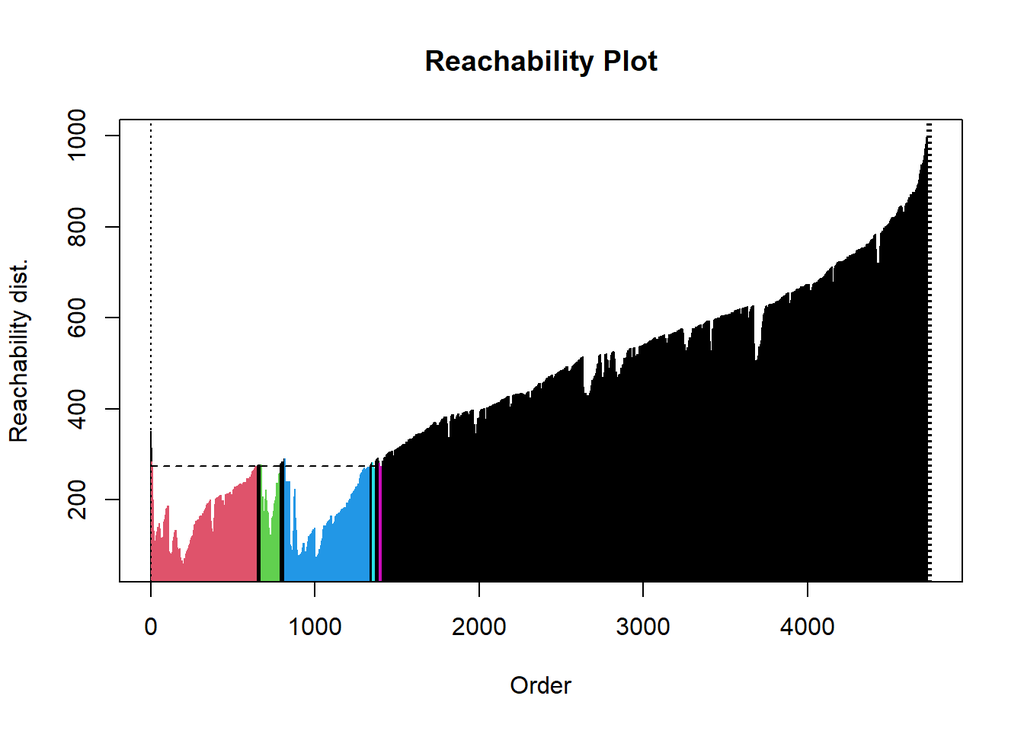

```r
clusters2 <- extractDBSCAN(res2, eps_cl = 275)
plot(clusters2)
```

Let’s take a better look at the groupings of values and outliers generated by the algorithm.

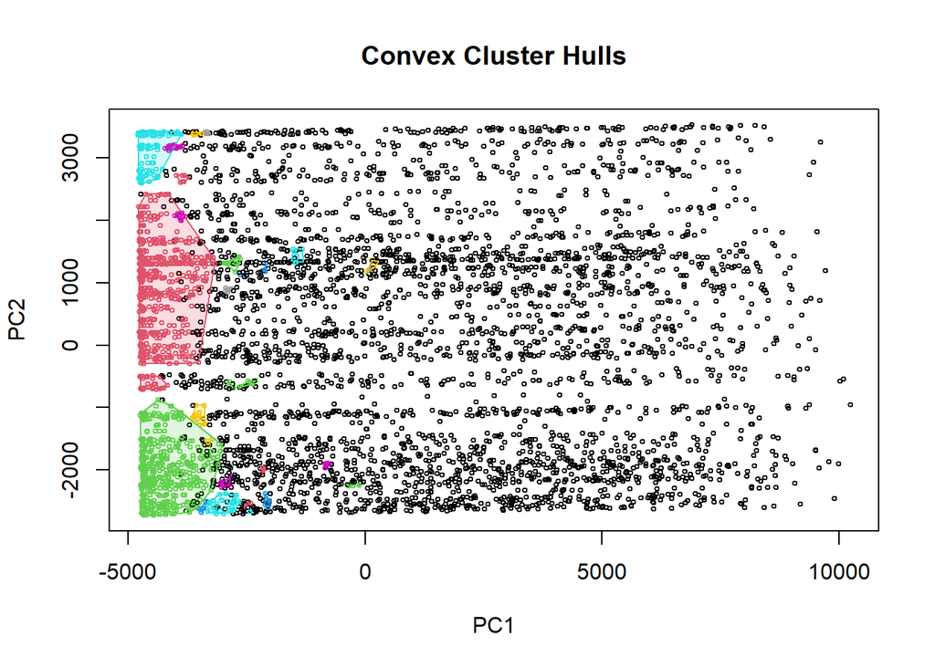

```r
hullplot(telecomNumericData, clusters)
```

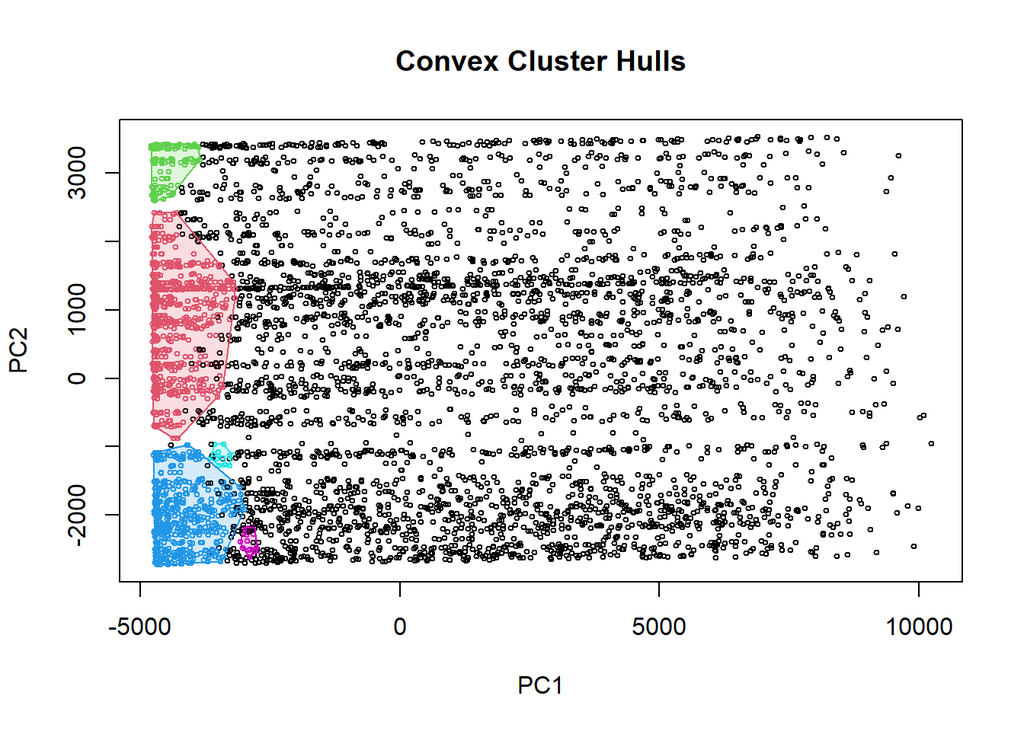

```r
hullplot(telecomNumericData, clusters2)
```

# 5 Preparation for C50: selection of training and test samples

```r
if(!require('caret')) install.packages('caret'); library('caret')
split_prop <- 0.75
indexes = createDataPartition(telecomCleanData$Customer.Status, p = split_prop, list = FALSE, times = 1)
train_data <- telecomCleanData[indexes, ]
test_data <- telecomCleanData[-indexes, ]
trainX <- train_data[, -32]
trainY <- train_data[, 32]
testX <- test_data[, -32]
testY <- test_data[, 32]
summary(trainX)
```

```
##     Gender               Age          Married          Number.of.Dependents
##  Length:3566        Min.   :19.00   Length:3566        Min.   :0.0000
##  Class :character   1st Qu.:33.00   Class :character   1st Qu.:0.0000
##  Mode  :character   Median :47.00   Mode  :character   Median :0.0000
##                     Mean   :47.59                      Mean   :0.3811
##                     3rd Qu.:62.00                      3rd Qu.:0.0000
##                     Max.   :80.00                      Max.   :6.0000
##     Zip.Code     Number.of.Referrals Tenure.in.Months    Offer
##  Min.   :90001   Min.   : 0.000      Min.   : 1.0     Length:3566
##  1st Qu.:92078   1st Qu.: 0.000      1st Qu.: 9.0     Class :character
##  Median :93433   Median : 0.000      Median :30.0     Mode  :character
##  Mean   :93448   Mean   : 1.889      Mean   :33.1
##  3rd Qu.:95324   3rd Qu.: 3.000      3rd Qu.:56.0
##  Max.   :96150   Max.   :10.000      Max.   :72.0
##  Phone.Service      Avg.Monthly.Long.Distance.Charges Multiple.Lines
##  Length:3566        Min.   : 1.01                     Length:3566
##  Class :character   1st Qu.:13.02                     Class :character
##  Mode  :character   Median :25.81                     Mode  :character
##                     Mean   :25.58
##                     3rd Qu.:38.06
##                     Max.   :49.99
##  Internet.Service   Internet.Type      Avg.Monthly.GB.Download
##  Length:3566        Length:3566        Min.   : 2.00
##  Class :character   Class :character   1st Qu.:13.00
##  Mode  :character   Mode  :character   Median :21.00
##                                        Mean   :26.26
##                                        3rd Qu.:30.00
##                                        Max.   :85.00
##  Online.Security    Online.Backup      Device.Protection.Plan
##  Length:3566        Length:3566        Length:3566
##  Class :character   Class :character   Class :character
##  Mode  :character   Mode  :character   Mode  :character
##
##
##
##  Premium.Tech.Support Streaming.TV       Streaming.Movies   Streaming.Music
##  Length:3566          Length:3566        Length:3566        Length:3566
##  Class :character     Class :character   Class :character   Class :character
##  Mode  :character     Mode  :character   Mode  :character   Mode  :character
##
```

[output cut: 15 more lines]

```
##  Max.   :118.65   Max.   :8684.8   Max.   :49.570   Max.   :150.000
##  Total.Long.Distance.Charges Total.Revenue      Churn.Category
##  Min.   :   1.15             Min.   :   46.92   Length:3566
##  1st Qu.: 142.57             1st Qu.:  912.24   Class :character
##  Median : 522.38             Median : 3114.20   Mode  :character
##  Mean   : 845.87             Mean   : 3754.99
##  3rd Qu.:1342.45             3rd Qu.: 6282.85
##  Max.   :3515.92             Max.   :11979.34
##  Churn.Reason       Tenure_Category    Age_Category       Service_Category
##  Length:3566        Length:3566        Length:3566        Length:3566
##  Class :character   Class :character   Class :character   Class :character
##  Mode  :character   Mode  :character   Mode  :character   Mode  :character
##
##
##
```

```r
summary(trainY)
```

```
##    Length     Class      Mode
##      3566 character character
```

```r
summary(testX)
```

```
##     Gender               Age          Married          Number.of.Dependents
##  Length:1186        Min.   :19.00   Length:1186        Min.   :0.0000
##  Class :character   1st Qu.:33.00   Class :character   1st Qu.:0.0000
##  Mode  :character   Median :48.00   Mode  :character   Median :0.0000
##                     Mean   :48.17                      Mean   :0.3609
##                     3rd Qu.:62.75                      3rd Qu.:0.0000
##                     Max.   :80.00                      Max.   :8.0000
##     Zip.Code     Number.of.Referrals Tenure.in.Months    Offer
##  Min.   :90003   Min.   : 0.000      Min.   : 1.00    Length:1186
##  1st Qu.:92117   1st Qu.: 0.000      1st Qu.: 9.00    Class :character
##  Median :93583   Median : 0.000      Median :31.00    Mode  :character
##  Mean   :93526   Mean   : 1.916      Mean   :33.09
##  3rd Qu.:95327   3rd Qu.: 3.000      3rd Qu.:57.00
##  Max.   :96150   Max.   :10.000      Max.   :72.00
##  Phone.Service      Avg.Monthly.Long.Distance.Charges Multiple.Lines
##  Length:1186        Min.   : 1.02                     Length:1186
##  Class :character   1st Qu.:13.17                     Class :character
##  Mode  :character   Median :25.80                     Mode  :character
##                     Mean   :25.46
##                     3rd Qu.:37.84
##                     Max.   :49.98
##  Internet.Service   Internet.Type      Avg.Monthly.GB.Download
##  Length:1186        Length:1186        Min.   : 2.00
##  Class :character   Class :character   1st Qu.:12.00
##  Mode  :character   Mode  :character   Median :20.00
##                                        Mean   :25.62
##                                        3rd Qu.:29.00
##                                        Max.   :85.00
##  Online.Security    Online.Backup      Device.Protection.Plan
##  Length:1186        Length:1186        Length:1186
##  Class :character   Class :character   Class :character
##  Mode  :character   Mode  :character   Mode  :character
##
##
##
##  Premium.Tech.Support Streaming.TV       Streaming.Movies   Streaming.Music
##  Length:1186          Length:1186        Length:1186        Length:1186
##  Class :character     Class :character   Class :character   Class :character
##  Mode  :character     Mode  :character   Mode  :character   Mode  :character
##
```

[output cut: 15 more lines]

```
##  Max.   :118.75   Max.   :8672.45   Max.   :48.950   Max.   :150.000
##  Total.Long.Distance.Charges Total.Revenue      Churn.Category
##  Min.   :   1.13             Min.   :   51.07   Length:1186
##  1st Qu.: 132.51             1st Qu.:  887.41   Class :character
##  Median : 495.54             Median : 3086.62   Mode  :character
##  Mean   : 859.48             Mean   : 3787.08
##  3rd Qu.:1423.00             3rd Qu.: 6372.38
##  Max.   :3536.64             Max.   :11795.78
##  Churn.Reason       Tenure_Category    Age_Category       Service_Category
##  Length:1186        Length:1186        Length:1186        Length:1186
##  Class :character   Class :character   Class :character   Class :character
##  Mode  :character   Mode  :character   Mode  :character   Mode  :character
##
##
##
```

```r
summary(testY)
```

```
##    Length     Class      Mode
##      1186 character character
```

We now check that there are no serious differences and the division of the data into training and test sets has been performed correctly using random sampling, the sets trainX, trainy contain 75% of the data, and testX, testy contain the remaining 25%.

Since the classes are unbalanced, being “Churned”: 1563, “Joined”: 230 and “Stayed”: 2959, I have chosen to use stratified sampling to ensure that the proportion of classes is maintained in both training and test sets. This ensures that the proportions of the classes (“Churned”, “Joined”, “Stayed”) in both sets are representative of the proportions in the original data set. The function “createDataPartition”, is in charge of performing this stratified sampling according to the target variable “Customer.Status”, and a partition ratio of 75% for the training set and 25% for the test set has been maintained. In this way, the allocation is randomized, but remains proportional to the different values of Customer.Status.

# 6 Rule generation

```r
trainY <-  as.factor(trainY)
model <- C50::C5.0(trainX, trainY,rules=TRUE )
```

```
## c50 code called exit with value 1
```

```r
summary(model)
```

```
##
## Call:
## C5.0.default(x = trainX, y = trainY, rules = TRUE)
##
##
## C5.0 [Release 2.07 GPL Edition]      Tue Jan 30 13:52:09 2024
## -------------------------------
##
## *** line 14 of `undefined.names': attribute `Phone.Service' has only one value `Yes'
##
## Error limit exceeded
```

We note that the variable Phone.Service only has a single value “Yes”. Therefore, it does not contribute anything to the construction of the tree since it does not provide any information to divide the data into different branches, and we can eliminate it from our training and testing models. Let’s check that it is not the only one.

```r
print(sapply(telecomCleanData, function(col) length(unique(col)) == 1))
```

```
##                            Gender                               Age
##                             FALSE                             FALSE
##                           Married              Number.of.Dependents
##                             FALSE                             FALSE
##                          Zip.Code               Number.of.Referrals
##                             FALSE                             FALSE
##                  Tenure.in.Months                             Offer
##                             FALSE                             FALSE
##                     Phone.Service Avg.Monthly.Long.Distance.Charges
##                              TRUE                             FALSE
##                    Multiple.Lines                  Internet.Service
##                             FALSE                              TRUE
##                     Internet.Type           Avg.Monthly.GB.Download
##                             FALSE                             FALSE
##                   Online.Security                     Online.Backup
##                             FALSE                             FALSE
##            Device.Protection.Plan              Premium.Tech.Support
##                             FALSE                             FALSE
##                      Streaming.TV                  Streaming.Movies
##                             FALSE                             FALSE
##                   Streaming.Music                    Unlimited.Data
##                             FALSE                             FALSE
##                          Contract                 Paperless.Billing
##                             FALSE                             FALSE
##                    Payment.Method                    Monthly.Charge
##                             FALSE                             FALSE
##                     Total.Charges                     Total.Refunds
##                             FALSE                             FALSE
##          Total.Extra.Data.Charges       Total.Long.Distance.Charges
##                             FALSE                             FALSE
##                     Total.Revenue                   Customer.Status
##                             FALSE                             FALSE
##                    Churn.Category                      Churn.Reason
##                             FALSE                             FALSE
##                   Tenure_Category                      Age_Category
##                              TRUE                             FALSE
##                  Service_Category
##                             FALSE
```

We can see that Phone.Service, Internet.Service and Tenure_Category have only one value, so we remove them from our sets. At the same time, if we look at the analysis that we did at the beginning, there were some variables with blanks, which can give problems in the generation of the tree as well, so we will eliminate them for this model and be able to perform it correctly.

```r
telecomTreeData <- telecomCleanData[, -which(names(telecomCleanData) %in% c("Phone.Service", "Internet.Service", "Tenure_Category", "Churn.Category", "Churn.Reason", "Service_Category"))]
```

```r
indexes = createDataPartition(telecomCleanData$Customer.Status, p = split_prop, list = FALSE, times = 1)
train_data <- telecomTreeData[indexes, ]
test_data <- telecomTreeData[-indexes, ]
trainX <- train_data[, -30]
trainY <- train_data[, 30]
testX <- test_data[, -30]
testY <- test_data[, 30]
```

```r
trainY <-  as.factor(trainY)
model <- C50::C5.0(trainX, trainY,rules=TRUE )
summary(model)
```

```
##
## Call:
## C5.0.default(x = trainX, y = trainY, rules = TRUE)
##
##
## C5.0 [Release 2.07 GPL Edition]      Tue Jan 30 13:52:10 2024
## -------------------------------
##
## Class specified by attribute `outcome'
##
## Read 3566 cases (31 attributes) from undefined.data
##
## Rules:
##
## Rule 1: (24, lift 2.9)
##  Number.of.Referrals <= 3
##  Tenure.in.Months > 3
##  Internet.Type = Cable
##  Online.Security = No
##  Contract = Month-to-Month
##  Monthly.Charge > 70.75
##  ->  class Churned  [0.962]
##
## Rule 2: (15, lift 2.9)
##  Age <= 64
##  Married = No
##  Number.of.Dependents <= 0
##  Tenure.in.Months > 3
##  Avg.Monthly.Long.Distance.Charges > 9.99
##  Internet.Type in {Cable, Fiber Optic}
##  Contract = Month-to-Month
##  Payment.Method = Mailed Check
##  ->  class Churned  [0.941]
##
## Rule 3: (13, lift 2.8)
##  Married = Yes
##  Number.of.Referrals <= 1
##  Tenure.in.Months <= 3
##  Internet.Type in {Cable, DSL}
##  ->  class Churned  [0.933]
```

[output cut: 179 more lines]

```
##   18.09% Online.Security
##   16.40% Monthly.Charge
##   14.44% Avg.Monthly.GB.Download
##   11.69% Married
##   10.68% Age
##    6.39% Online.Backup
##    5.75% Unlimited.Data
##    3.48% Streaming.Music
##    1.65% Total.Revenue
##    0.64% Avg.Monthly.Long.Distance.Charges
##    0.22% Device.Protection.Plan
##    0.14% Streaming.TV
##
##
## Time: 0.1 secs
```

- Rule 16: There are 805 cases in the training data set that meet all the conditions of this rule, and this rule is 1.4 times more likely to be true than if the variables were independent. ++ If Age is less than or equal to 64. ++ And Number.of.Referrals is greater than 0. ++ And Paperless.Billing is “No”. ++ And Total.Charges is greater than 4681.75. ++ So, it classifies as “Stayed” with a confidence of 92.7%.

## 6.1 Graphic and Text format of the Rules

[output not shown]

[output cut: 28 more lines]

[output not shown]

[output not shown]

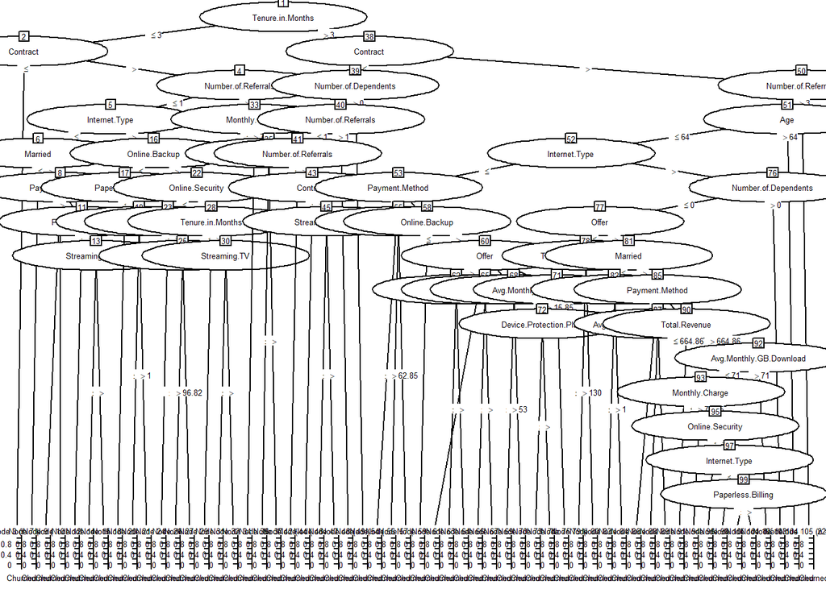

```r
library(grid)
model <- C50::C5.0(trainX, trainY)
plot(model,gp = gpar(fontsize = 5))
```

The model is too large to see it clearly. To see it better, we can export the image and zoom into the areas we want. Also, we can show subbranches with the subtree parameter. In the image above, we can see how above each variable balloon, we have a number that represents the node. These subbranches will show us only the results from that node down.

[output not shown]

[output cut: 28 more lines]

[output not shown]

[output not shown]

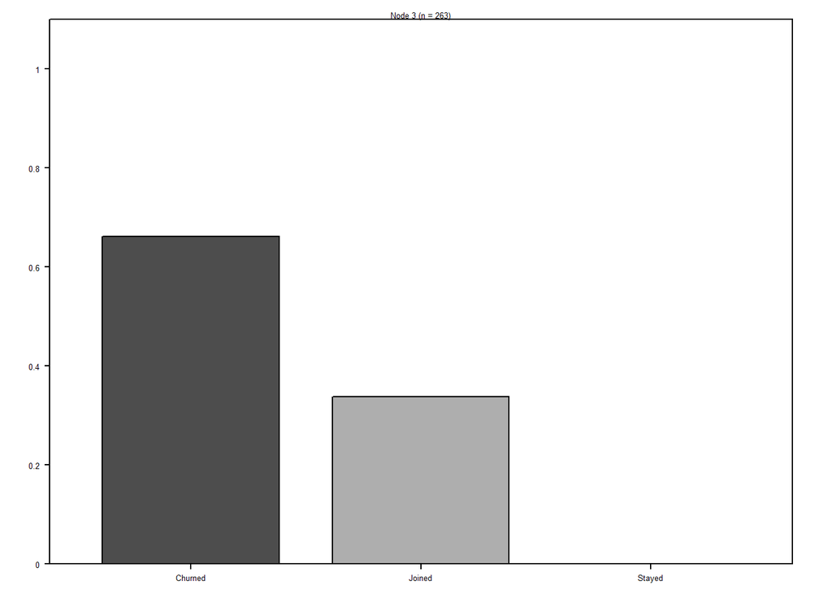

```r
plot(model,gp = gpar(fontsize = 5), subtree = 3)
```

[output not shown]

[output cut: 25 more lines]

[output not shown]

[output not shown]

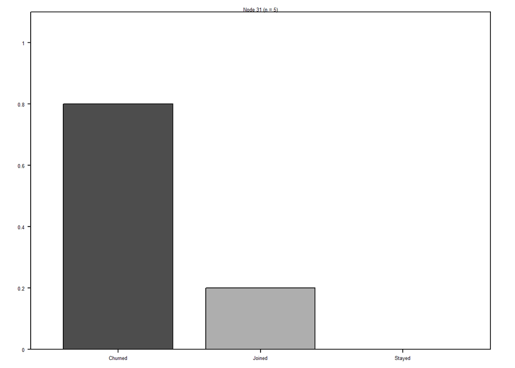

```r
plot(model,gp = gpar(fontsize = 5), subtree = 31)
```

[output not shown]

[output cut: 25 more lines]

[output not shown]

[output not shown]

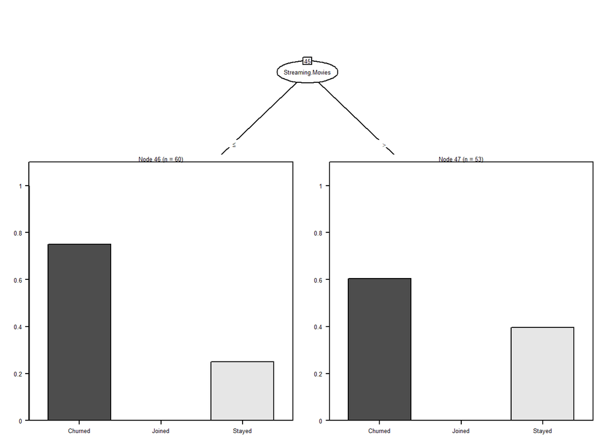

```r
plot(model,gp = gpar(fontsize = 5), subtree = 45)
```

## 6.2 Confusion matrix

Let’s calculate the confusion matrix to identify the types of errors made.

```r
mat_conf<-table(testY,Predicted=predict(model, testX, type="class"))
mat_conf
```

```
##          Predicted
## testY     Churned Joined Stayed
##   Churned     268     20    102
##   Joined       31     26      0
##   Stayed       85      0    654
```

```r
porcentaje_correct<-100 * sum(diag(mat_conf)) / sum(mat_conf)
print(sprintf("The %% of records correctly classified is: %.4f %%",porcentaje_correct))
```

```
## [1] "The % of records correctly classified is: 79.9325 %"
```

We note that the prediction is good enough. However, the percentage could be increased if we do more tests, modifying the trial parameter. In this way, it would be generating the models that we specify, choosing the rules and detailing them more taking the information of all the models, generating one with a greater base. With the gmodels package we get more complete information:

```r
if(!require(gmodels)){
    install.packages('gmodels', repos='http://cran.us.r-project.org')
    library(gmodels)
}
CrossTable(testY, predict(model, testX, type="class"), prop.chisq=FALSE, prop.c=FALSE, prop.r=FALSE, dnn=c('Reality', 'Prediction'))
```

```
##
##
##    Cell Contents
## |-------------------------|
## |                       N |
## |         N / Table Total |
## |-------------------------|
##
##
## Total Observations in Table:  1186
##
##
##              | Prediction
##      Reality |   Churned |    Joined |    Stayed | Row Total |
## -------------|-----------|-----------|-----------|-----------|
##      Churned |       268 |        20 |       102 |       390 |
##              |     0.226 |     0.017 |     0.086 |           |
## -------------|-----------|-----------|-----------|-----------|
##       Joined |        31 |        26 |         0 |        57 |
##              |     0.026 |     0.022 |     0.000 |           |
## -------------|-----------|-----------|-----------|-----------|
##       Stayed |        85 |         0 |       654 |       739 |
##              |     0.072 |     0.000 |     0.551 |           |
## -------------|-----------|-----------|-----------|-----------|
## Column Total |       384 |        46 |       756 |      1186 |
## -------------|-----------|-----------|-----------|-----------|
##
##
```

# 7 Different variation and algorithmic approach

Let’s try now to increase the trials parameter to do what I have explained above and increase our hit percentage.

```r
model2 <- C50::C5.0(trainX, trainY, trials = 10)
summary(model2)
```

```
##
## Call:
## C5.0.default(x = trainX, y = trainY, trials = 10)
##
##
## C5.0 [Release 2.07 GPL Edition]      Tue Jan 30 13:52:17 2024
## -------------------------------
##
## Class specified by attribute `outcome'
##
## Read 3566 cases (31 attributes) from undefined.data
##
## -----  Trial 0:  -----
##
## Decision tree:
##
## Tenure.in.Months <= 3:
## :...Contract in {One Year,Two Year}: Joined (19)
## :   Contract = Month-to-Month:
## :   :...Number.of.Referrals > 1:
## :       :...Monthly.Charge <= 75.5: Joined (19)
## :       :   Monthly.Charge > 75.5:
## :       :   :...Paperless.Billing = Yes: Churned (8/2)
## :       :       Paperless.Billing = No: Joined (3)
## :       Number.of.Referrals <= 1:
## :       :...Internet.Type in {Cable,DSL}:
## :           :...Married = Yes: Churned (13)
## :           :   Married = No:
## :           :   :...Payment.Method = Credit Card: Joined (65/26)
## :           :       Payment.Method = Mailed Check: Churned (15/4)
## :           :       Payment.Method = Bank Withdrawal:
## :           :       :...Paperless.Billing = Yes: Churned (59/21)
## :           :           Paperless.Billing = No:
## :           :           :...Streaming.Music = No: Joined (27/8)
## :           :               Streaming.Music = Yes: Churned (3)
## :           Internet.Type = Fiber Optic:
## :           :...Online.Backup = Yes:
## :               :...Paperless.Billing = Yes: Churned (29/6)
## :               :   Paperless.Billing = No:
## :               :   :...Tenure.in.Months <= 1: Churned (2)
```

[output cut: 991 more lines]

```
##   42.96% Streaming.Movies
##   40.10% Avg.Monthly.GB.Download
##   34.72% Avg.Monthly.Long.Distance.Charges
##   30.93% Streaming.TV
##   28.10% Online.Backup
##   22.91% Unlimited.Data
##   22.07% Total.Revenue
##   21.14% Total.Refunds
##   17.98% Paperless.Billing
##   15.40% Total.Long.Distance.Charges
##   13.43% Device.Protection.Plan
##   13.01% Gender
##
##
## Time: 0.4 secs
```

We can see that the model has been run 10 times, and the percentage will have increased if it has been a good repetition.

```r
predicted_model <- predict(model2, testX, type="class")
print(sprintf("La precisión del árbol es: %.4f %%",100*sum(predicted_model == testY) / length(predicted_model)))
```

```
## [1] "La precisión del árbol es: 81.9562 %"
```

We note that the accuracy has increased by 2%, so the quality has increased slightly. At this level of values, the higher the quality, increasing the quality closer to 100% becomes an exponential difficulty, since making a more accurate model is more and more complicated.

## 7.1 Comparison of the results with the previous supervised model

Furthermore, if we compare the confusion matrices:

```r
CrossTable(testY, predict(model2, testX, type="class"), prop.chisq=FALSE, prop.c=FALSE, prop.r=FALSE, dnn=c('Reality', 'Prediction'))
```

```
##
##
##    Cell Contents
## |-------------------------|
## |                       N |
## |         N / Table Total |
## |-------------------------|
##
##
## Total Observations in Table:  1186
##
##
##              | Prediction
##      Reality |   Churned |    Joined |    Stayed | Row Total |
## -------------|-----------|-----------|-----------|-----------|
##      Churned |       278 |        13 |        99 |       390 |
##              |     0.234 |     0.011 |     0.083 |           |
## -------------|-----------|-----------|-----------|-----------|
##       Joined |        32 |        25 |         0 |        57 |
##              |     0.027 |     0.021 |     0.000 |           |
## -------------|-----------|-----------|-----------|-----------|
##       Stayed |        70 |         0 |       669 |       739 |
##              |     0.059 |     0.000 |     0.564 |           |
## -------------|-----------|-----------|-----------|-----------|
## Column Total |       380 |        38 |       768 |      1186 |
## -------------|-----------|-----------|-----------|-----------|
##
##
```

We can therefore conclude that the second model is better than the first one, both in terms of the error rate and the number and quality of the rules, since the first one has 20 rules, while the improved model uses a set of 10 trees, and this generates a single stronger model.

# 8 Conclusions and personal opinions, based on the results.

## 8.1 Possible limitations of the selected data

In the supervised model, we have more at hand real data, statistics, and visualization of this data. In addition, the factor of generating rules, in my opinion, is the determining factor for most of the analysis, since it allows us to obtain these rules and apply them to the company, so that we can improve the quality of those people, offers or services that meet the conditions specified in each rule generated. In the unsupervised model, we can try to generate a model that groups new customers into Stayed or Churned groups, in order to try to predict what the new customer will do.

## 8.2 Possible risks of using each model

- The results of unsupervised kmeans models require subjective interpretation. Cluster assignment may not have a single, clear interpretation, and different people may interpret the results differently. In addition, the choice of the optimal number of clusters may also be subjective and not always obvious, and using the wrong number of clusters may lead to misinterpretation of the results. In addition, they are more sensitive to noise and the presence of outliers in the data, and this negatively affects quality. Also, as I have commented in the previous section, the validation of the results is more complicated, since, unlike supervised models where specific metrics are used, the evaluation of the quality of the clusters in unsupervised models can be subjective. Finally, some clustering algorithms, especially the Calinski-Harabasz criterion, can be computationally expensive, especially when working with large data sets as in this case.
- For supervised models, such as the decision tree, a common risk is overfitting, where the model fits the training data too closely and does not generalize well to new data. This can occur especially if the model is very complex relative to the amount of data available. Also, as has happened in this case, when the classes in the training data are unbalanced and there are many more instances of one class than another, the model may have difficulty learning patterns in the minority class and become biased toward the majority class. Another very common risk is the possibility of inheriting biases present in the training data. If the training data contain social or cultural biases, the model may replicate and amplify those biases, leading to discriminatory decisions. Finally, as with the unsupervised model, the presence of noise can negatively affect model performance and lead to incorrect predictions.